# Maternal Cardiovascular-Related Single Nucleotide Polymorphisms, Genes, and Gene Regulatory Networks Associated with Early-Onset Preeclampsia

# Maternal Cardiovascular-Related Single Nucleotide Polymorphisms, Genes, and Gene Regulatory Networks Associated with Early-Onset Preeclampsia

## Preeclampsia review

- Early signs of preeclampsia include high blood pressure and protein in urine
- Caused by the placenta
- 2 - 8% worldwide
- 63k deaths worldwide
- Earlier occurrence associated with worse outcomes
- 50 women per year die in US out of 4M births

## Early-Onset Preeclampsia (EOPE)

- A subset of PE
- Distinguishing characteristics: – Develops before 34 weeks of gestation. (Late Onset is after 37 weeks) – EOPE is often complicated by IUGR (Interuterine Growth Restriction) – EOPE has clear placental pathology – Leision of uteralplacental malperfusion

## Idea

- EOPE may have an underlying genetic predisposition, (studies show family history a factor).
- Many previous genetic investigations have looked at genes involved in ~10 processes such as angiogenesis and lipid metabolism
- There are some known associations between preeclampsia and cardiovascular and metabolic disease such as chronic hypertension and diabetes, and women with a history of preeclampsia more likely to get these diseases
- There are racial differences in rates of preeclampsia, NHOPI and Filipinos have increased risk

## Data collected

- MetaboChip with 196,7250 SNPs associated with metabolic and cardiovascular traits
- All raw data is in an Illumina FinalReport txt file
  - 400MB uncompressed
  - TSV format (skip the first 9 lines)
  - 11.8M lines. 1 line for each SNP.
- Clinical data in clinical.csv

## Goal

- Find associations with EOPE
  - In SNPS (cardiovascular and metabolic in particular)
  - Genes
  - Regulatory pathways

## Results

- No SNPs found to be correlated (after corrections)
- Through gene-based tests:

## Sections

```r
source("setup.r")
```

```
[1] "Notice: cache already initialized. Keeping existing cache."
```

```
[conflicted] Removing existing preference
```

```
[conflicted] Will prefer dplyr::filter over any other package
```

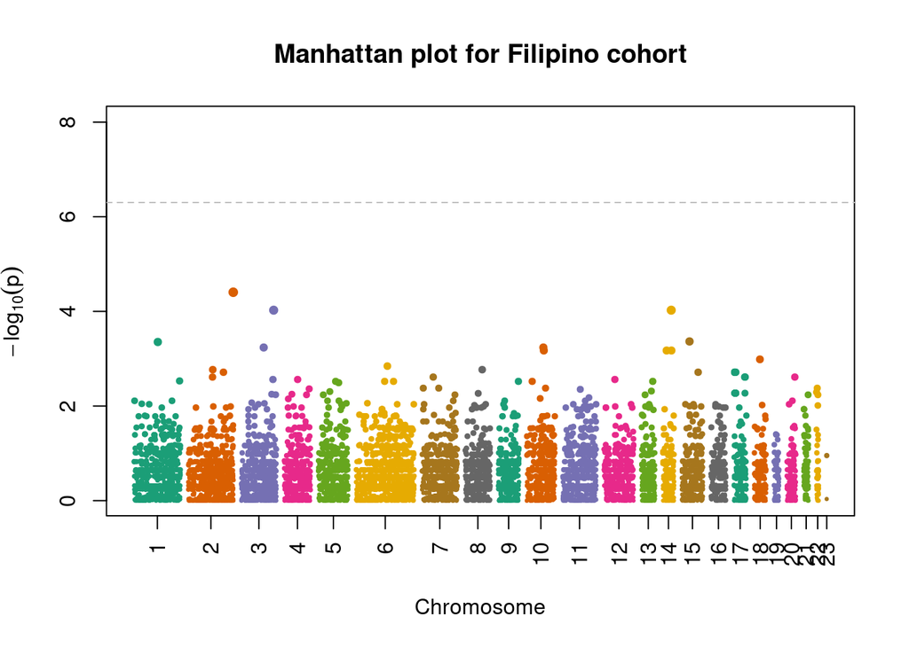

```r
filips = pe.getPValsAll(suffix = "Filip")
pvalueResults = filips %>% dplyr::arrange(chr)
manhattanPlot(pvalueResults$minPval, pvalueResults$chr, signif=5e-7, main = "Manhattan plot for Filipino cohort")
```

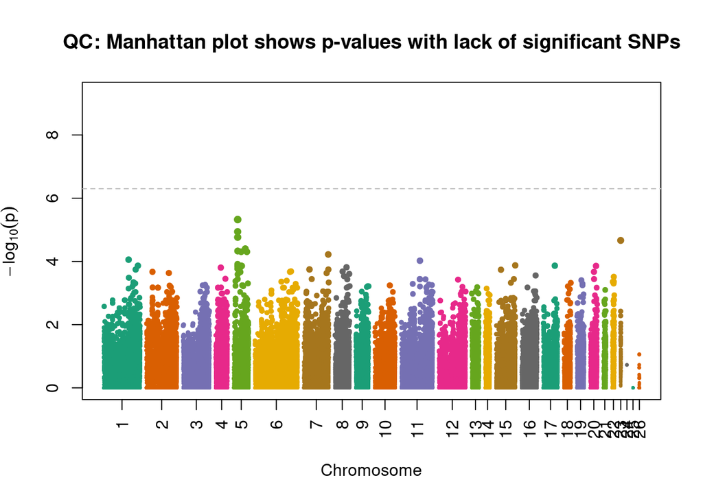

```r
allPs = pe.getPValsAll("All")
pvalueResults = allPs %>% dplyr::arrange(chr)
manhattanPlot(pvalueResults$minPval, pvalueResults$chr, signif=5e-7, main = "QC: Manhattan plot shows p-values with lack of significant SNPs")
```

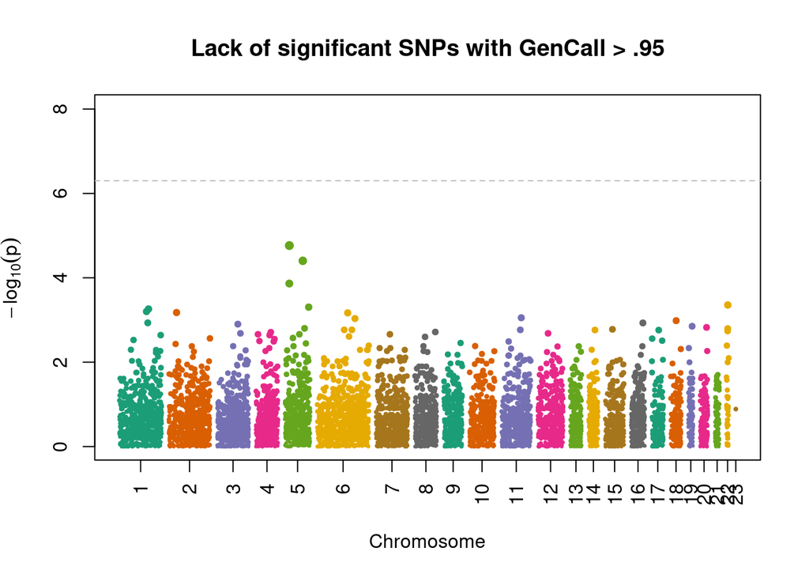

```r
# Drop any with calls less than .95, non-calls, and monomorphic
allPsQC = pe.getPValsAll("QC")
pvalueResults = allPsQC %>% dplyr::arrange(chr)
manhattanPlot(pvalueResults$minPval, pvalueResults$chr, signif=5e-7, main = "Lack of significant SNPs with GenCall > .95")
```

#### Let’s see if any clusters emerge in Preeclampsia vs Control

```r
source("setup.r")
```

```
[1] "Notice: cache already initialized. Keeping existing cache."
```

```
[conflicted] Removing existing preference
```

```
[conflicted] Will prefer dplyr::filter over any other package
```

```r
library(rgl)
```

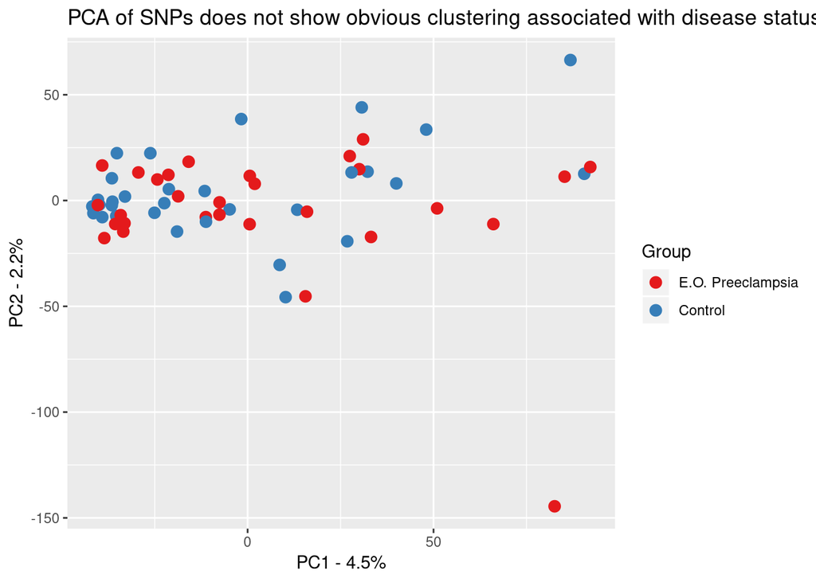

```r
clinical = pe.getClinicalInfo()

plotTemplateDisease = function(pca, plotTitle, clinicalData = pe.getClinicalInfo()) {
  df <- cbind(clinicalData, as.data.frame(pca$x))
  importance = summary(pca)$importance
  label1 = importance[2] * 100
  label2 = importance[5] * 100
  ggplot(df, aes(x=PC1, y=PC2, color=as.factor(preeclampsia))) + geom_point(size = 3) +
  scale_color_manual(values = brewer.pal(n = 8, name = "Set1"), labels = c("E.O. Preeclampsia", "Control"), name = "Group") +
  labs(title = plotTitle, x = glue("PC1 - {round(label1, 1)}%"), y = glue("PC2 - {round(label2, 1)}%"))
}

# Let's do the PCA after dropping noncalls, monomorphisms and standardizing items to -1,0,1
pca = prcomp(pe.getNumericAlleleMatrix())
plotTemplateDisease(pca, "PCA of SNPs does not show obvious clustering associated with disease status")
```

# We can also try a 3D PCA:

```r
plot3d(x=pca$x[,1],y=pca$x[,2],z=pca$x[,3], col = c("red","blue")[clinical$preeclampsia + 1], type="s",radius=3)
```

### Nothing jumps out. Let’s double check ethnicities, as we should see clusters from SNPS there.

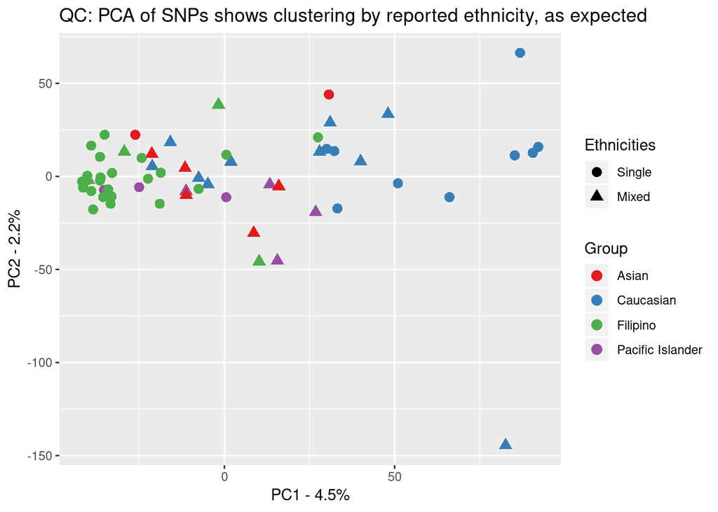

```r
clinical = pe.getClinicalInfo()

plotTemplate = function(pca, plotTitle){
  df <- cbind(clinical, as.data.frame(pca$x))
  importance = summary(pca)$importance
  label1 = importance[2] * 100
  label2 = importance[5] * 100

  ggplot(df, aes(x=PC1, y=PC2, color=clinical$ethnicityCategory, shape = as.factor(mixed))) +
  geom_point(size = 3) +
  scale_color_manual(values = brewer.pal(n = 8, name = "Set1"), labels = levels(clinical$ethnicityCategory), name = "Group") +
  labs(title = plotTitle, x = glue("PC1 - {round(label1, 1)}%"), y = glue("PC2 - {round(label2, 1)}%")) +
  scale_shape_manual(name = "Ethnicities", labels = c("Single", "Mixed"), values = c(16,17) )
}

pca = prcomp(pe.getNumericAlleleMatrix())
plotTemplate(pca, "QC: PCA of SNPs shows clustering by reported ethnicity, as expected")
```

# Let’s do a 3D plot of ethnicity

```r
plot3d(x=pca$x[,1],y=pca$x[,2],z=pca$x[,3], col = brewer.pal(n = 4, name = "Set1")[clinical$ethnicityCategory], type="s",radius=3)
```

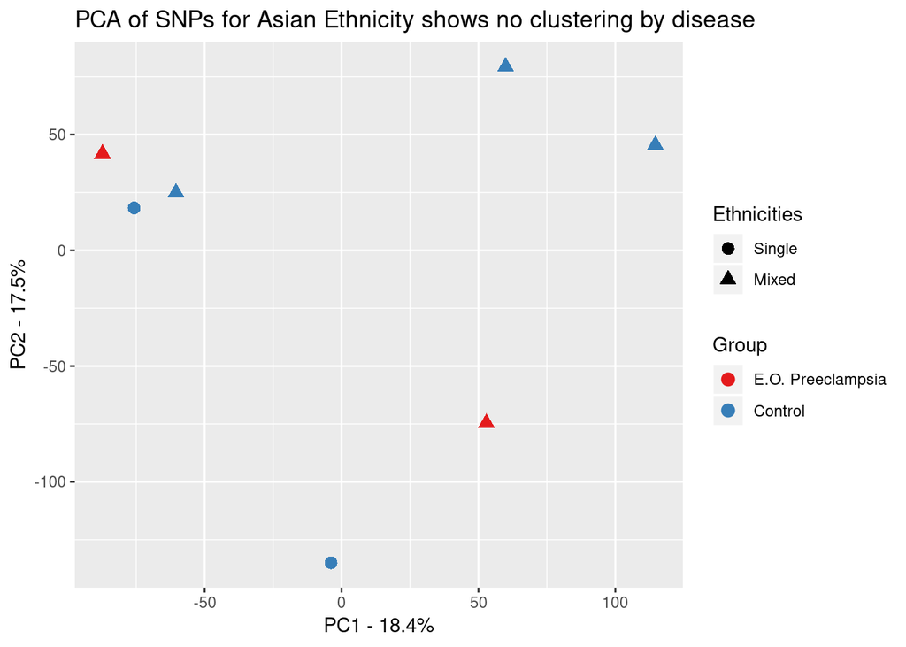

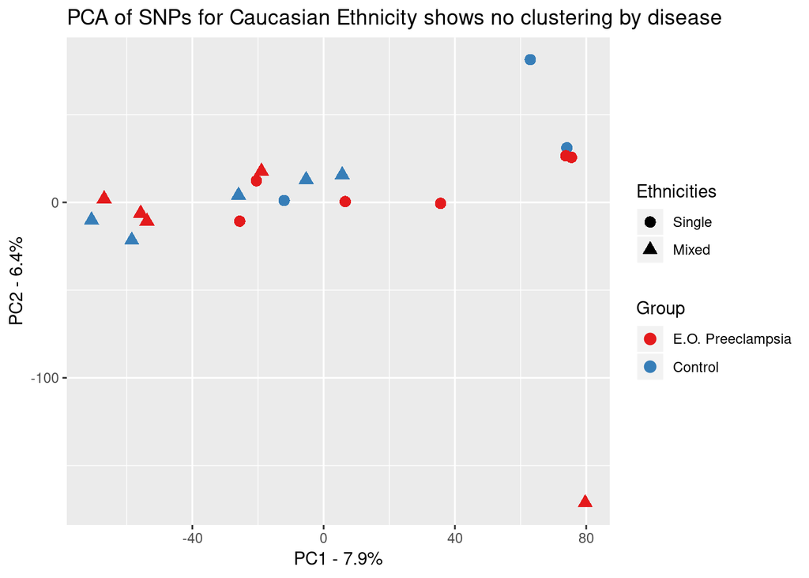

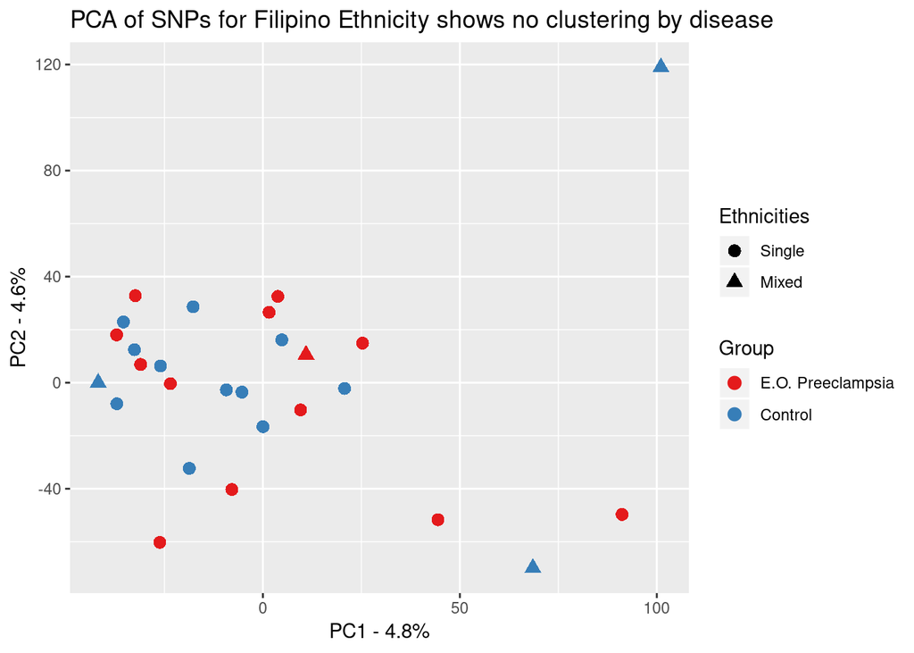

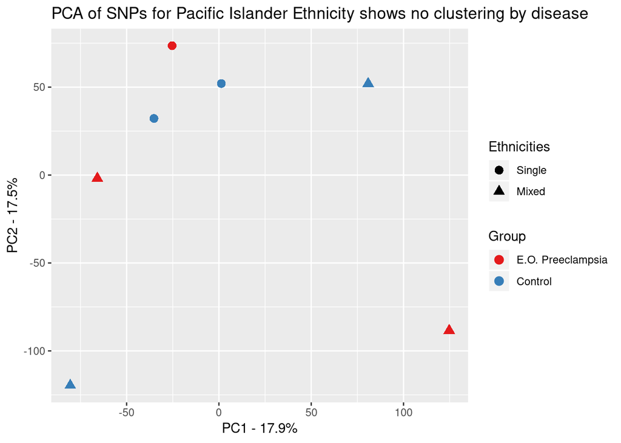

```r
clinical = pe.getClinicalInfo()

plotTemplateDiseaseEth = function(pca, plotTitle, clinicalData = pe.getClinicalInfo()) {
  df <- cbind(clinicalData, as.data.frame(pca$x))
  importance = summary(pca)$importance
  label1 = importance[2] * 100
  label2 = importance[5] * 100
  ggplot(df, aes(x=PC1, y=PC2, color=as.factor(preeclampsia),  shape = as.factor(mixed))) + geom_point(size = 3) +
  scale_color_manual(values = brewer.pal(n = 8, name = "Set1"), labels = c("E.O. Preeclampsia", "Control"), name = "Group") +
  scale_shape_manual(name = "Ethnicities", labels = c("Single", "Mixed"), values = c(16,17) ) +
#  geom_text(aes(label=ifelse(PC1 > 50 & (PC2 > 50 | PC2 < -50), patientId, "")),hjust=-.5, vjust=-.5, size = 2.5, color = "black") +
  labs(title = plotTitle, x = glue("PC1 - {round(label1, 1)}%"), y = glue("PC2 - {round(label2, 1)}%"))
}

domRecMatrix = pe.getNumericAlleleMatrix()
ress = lapply(levels(clinical$ethnicityCategory), function (name) {
  groupIds = clinical$ethnicityCategory == name
  pca = prcomp(domRecMatrix[groupIds,])
  plotTemplateDiseaseEth(pca, glue("PCA of SNPs for {name} Ethnicity shows no clustering by disease"), clinical[groupIds,])
})
ress
```

```r
source("setup.r")
```

```
[1] "Notice: cache already initialized. Keeping existing cache."
```

```
[conflicted] Removing existing preference
```

```
[conflicted] Will prefer dplyr::filter over any other package
```

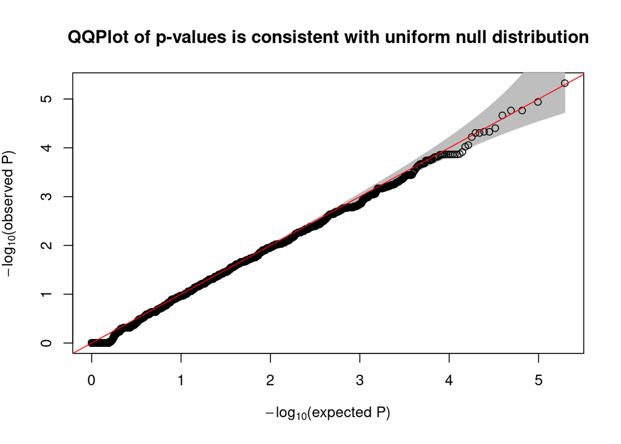

```r
qqPlot(pe.getPValsAll()$minPval, main = "QQPlot of p-values is consistent with uniform null distribution")
```

```r
source("setup.r")
```

```
[1] "Notice: cache already initialized. Keeping existing cache."
```

```
[conflicted] Removing existing preference
```

```
[conflicted] Will prefer dplyr::filter over any other package
```

# Look at the top SNPs before correction

```r
res = lapply(c("dominant", "codominant", "recessive", "overdominant", "log-additive"), function (modelName) {
  cache.get(modelName, function () stop("Use thread.r to compute pvals.")) %>% as.data.frame %>% rownames_to_column(var = "snp") %>% arrange_at(3) %>% dplyr::slice(1:10) %>% select(-one_of("comments"))
})

res
```

```
[[1]]
          snp     dominant
1   rs7804641 2.271119e-05
2     rs30117 4.810937e-05
3  rs10482796 1.335995e-04
4   rs6604616 1.366858e-04
5  rs11774014 2.088724e-04
6    rs209549 2.138686e-04
7   rs4512191 2.138686e-04
8   rs1946016 2.169683e-04
9   rs1728232 2.341614e-04
10  rs4822422 2.341614e-04

[[2]]
             snp   codominant
```

[output cut: 49 more lines]

# Look at the top SNPs after correction

```r
res = lapply(c("dominant", "codominant", "recessive", "overdominant", "log-additive"), function (modelName) {
  Bonferroni.sig(cache.get(modelName, function () stop("Use thread.r to compute pvals.")), model = modelName, alpha = 0.05, include.all.SNPs=FALSE)
})
```

```
number of tests:  132667
alpha: 0.05
corrected alpha: 3.768835e-07
   No significant SNPs after Bonferroni correction
number of tests:  132709
alpha: 0.05
corrected alpha: 3.767642e-07
   No significant SNPs after Bonferroni correction
number of tests:  132692
alpha: 0.05
corrected alpha: 3.768125e-07
   No significant SNPs after Bonferroni correction
number of tests:  132669
alpha: 0.05
corrected alpha: 3.768778e-07
   No significant SNPs after Bonferroni correction
number of tests:  132697
alpha: 0.05
corrected alpha: 3.767983e-07
   No significant SNPs after Bonferroni correction
```

```r
source("setup.r")
```

```
[1] "Notice: cache already initialized. Keeping existing cache."
```

```
[conflicted] Removing existing preference
```

```
[conflicted] Will prefer dplyr::filter over any other package
```

## Let’s read in the clinical data

```r
clinicalRaw = read_csv(pe.clinicalDataPath, col_types = cols())
nrow(clinicalRaw)
```

```
[1] 109
```

```r
head(clinicalRaw)
```

| patientId | preeclampsia | momAge | bmi | gestAge | ethnicity1 | ethnicityPercent1 | ethnicity2 | ethnicityPercent2 | ethnicity3 | ethnicityPercent3 | ethnicityCategory | primaGravida | 3HrGlucose1HrGlucola | gdm | iugr | abruption | daughter | babyWgtGram | placentaWgtGram |
| --- | --- | --- | --- | --- | --- | --- | --- | --- | --- | --- | --- | --- | --- | --- | --- | --- | --- | --- | --- |
| 18 | 1 | 18 | 18.9 | 33.0 | Hawaiian | 37.5 | Caucasian | 25 | Chinese | 25 | Pacific Islander | 0 | NA | 0 | 1 | 0 | 1 | 1294 | NA |
| 91 | 1 | 18 | 25.7 | 32.5 | Chinese | NA | American Indian | NA | Hawaiian | NA | Asian | 1 | NA | 0 | 0 | 0 | 0 | 1692 | NA |
| 36 | 0 | 19 | 18.9 | 39.6 | Filipino | 100.0 | NA | NA | NA | NA | Filipino | 1 | NA | 0 | 0 | 0 | 1 | 2821 | 384 |
| 52 | 0 | 19 | 22.7 | 40.0 | Mexican | 100.0 | NA | NA | NA | NA | Caucasian | 1 | NA | 0 | 0 | 0 | 0 | 3640 | 365 |
| 11 | 1 | 19 | NA | 33.6 | Filipino | 100.0 | NA | NA | NA | NA | Filipino | 1 | NA | 0 | 1 | 0 | 1 | 1588 | NA |
| 12 | 1 | 20 | 21.9 | 32.1 | Caucasian | 100.0 | NA | NA | NA | NA | Caucasian | 1 | NA | 0 | 0 | 0 | 0 | 1770 | NA |

### Filter Clinical

49 of the mothers were excluded due to lack of adequate maternal sample. Exclude these from clinical

```r
clinical = pe.getClinicalInfo()
skim_tee(clinical)
```

```
Skim summary statistics
 n obs: 60
 n variables: 21

── Variable type:character ──────────────────────────────────────────────────────────────────────────────────────────────────────────────────────────────
   variable missing complete  n min max empty n_unique
 ethnicity1       0       60 60   6  12     0       11
 ethnicity2      37       23 60   5  15     0       10
 ethnicity3      44       16 60   7  19     0        8

── Variable type:factor ─────────────────────────────────────────────────────────────────────────────────────────────────────────────────────────────────
          variable missing complete  n n_unique
 ethnicityCategory       0       60 60        4
                       top_counts ordered
 Fil: 27, Cau: 19, Asi: 7, Pac: 7   FALSE

── Variable type:integer ────────────────────────────────────────────────────────────────────────────────────────────────────────────────────────────────
             variable missing complete  n   mean    sd p0    p25   p50
 3HrGlucose1HrGlucola      24       36 60 126.06 28.61 85 103    121.5
            abruption       0       60 60   0.13  0.34  0   0      0
             daughter       0       60 60   0.52  0.5   0   0      1
                  gdm       0       60 60   0.1   0.3   0   0      0
                 iugr       0       60 60   0.15  0.36  0   0      0
                mixed       0       60 60   0.38  0.49  0   0      0
               momAge       0       60 60  29.6   5.71 18  26     31
            patientId       0       60 60  57.05 31.08  2  32.75  59.5
         preeclampsia       0       60 60   0.52  0.5   0   0      1
         primaGravida       0       60 60   0.35  0.48  0   0      0
    p75 p100     hist
 145.75  195 ▇▅▇▅▃▂▃▁
   0       1 ▇▁▁▁▁▁▁▁
   1       1 ▇▁▁▁▁▁▁▇
   0       1 ▇▁▁▁▁▁▁▁
   0       1 ▇▁▁▁▁▁▁▂
   1       1 ▇▁▁▁▁▁▁▅
  34      42 ▅▂▃▆▇▇▁▂
  82.25  102 ▅▃▃▅▃▅▅▇
   1       1 ▇▁▁▁▁▁▁▇
   1       1 ▇▁▁▁▁▁▁▅

── Variable type:numeric ────────────────────────────────────────────────────────────────────────────────────────────────────────────────────────────────
          variable missing complete  n    mean      sd    p0     p25
       babyWgtGram       0       60 60 2398.94 1013.13 730   1552.5
               bmi       5       55 60   25.45    6.41  18.6   21.2
 ethnicityPercent1       9       51 60   78.71   31.9    1     50
 ethnicityPercent2      51        9 60   31.11   18.96   5     12.5
 ethnicityPercent3      55        5 60   29.5    13.39  12.5   25
           gestAge       0       60 60   35.66    4.04  27     32.88
   placentaWgtGram      33       27 60  351.43  105.06 165    266.5
     p50     p75   p100     hist
 2386    3345.75 4193   ▅▆▇▃▂▅▇▃
   23.2    26.95   48.5 ▇▅▂▂▁▁▁▁
  100     100     100   ▁▁▁▃▁▁▁▇
   25      50      50   ▂▃▁▃▁▁▁▇
   25      37.5    47.5 ▃▁▇▁▁▃▁▃
   34.75   39.4    41.2 ▂▂▂▆▃▁▇▆
  366     424     533   ▃▃▂▃▇▂▃▃
```

### Now let’s create a numerical version of the clinical data for PCA and other methods

```r
clinicalNumeric = pe.getClinicalAsNumerics()
clinicalNumeric[1:5,]
```

| preeclampsia | momAge | gestAge | ethnicityCategory | primaGravida | gdm | iugr | abruption | daughter | babyWgtGram |
| --- | --- | --- | --- | --- | --- | --- | --- | --- | --- |
| 1 | 38 | 28.0 | 1 | 1 | 0 | 0 | 1 | 1 | 938 |
| 1 | 34 | 33.3 | 2 | 1 | 0 | 1 | 0 | 0 | 1619 |
| 1 | 22 | 30.1 | 4 | 1 | 0 | 0 | 1 | 0 | 1163 |
| 1 | 34 | 31.3 | 1 | 0 | 0 | 0 | 1 | 0 | 1395 |
| 1 | 34 | 29.5 | 1 | 0 | 0 | 1 | 0 | 1 | 958 |

### Let’s see any correlations in the clinical data

In the plot below, we see only expected correlations.

- Preeclampsia negatively correlates with gestAge and babyWgtGram
- If it’s your first baby (primaGravida) you are likely younger (momAge)
- If your baby has IUGR it weighs less (babyWgtGram)
- IUGR and preeclampsia are positively correlated
- A longer gestAge correlates with a heavier birthweight (babyWgtGram)

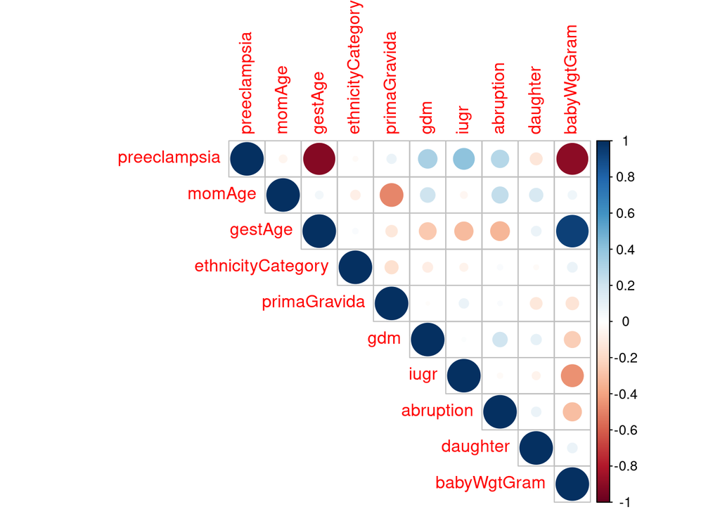

```r
corrplot(cor(clinicalNumeric), method="circle", type="upper")
```

Let’s check correlation of patients just as a sanity check. We should not see anything too extreme.

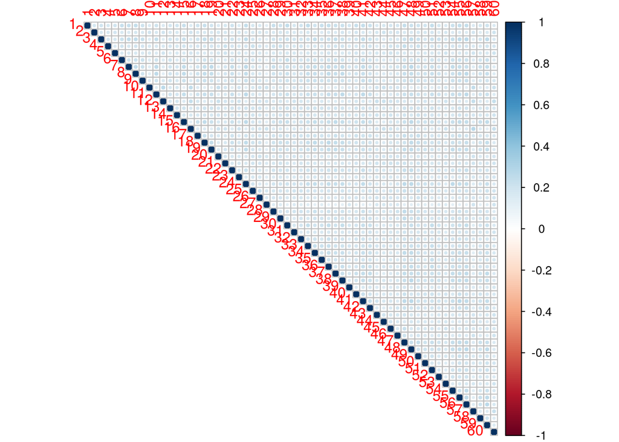

```r
# todo: try different row/column removal strategies
corrplot(pe.getNumericAlleleMatrix() %>% t %>% cor, method="circle", type="upper")
```

```r
source("setup.r")
```

```
[1] "Notice: cache already initialized. Keeping existing cache."
```

```
[conflicted] Removing existing preference
```

```
[conflicted] Will prefer dplyr::filter over any other package
```

### Let’s generate a Phylogenetic Tree

```r
tree = cache.get("phylotree", function() {
  write_tsv(pe.getSimpleSNPFormatForPhyloTree(), "../output/simplesnp.tsv")

  # Now run snphylo: http://chibba.pgml.uga.edu/snphylo/
  # We assume it is stored in the ignore folder
  system("../ignore/SNPhylo/snphylo.sh -s ../output/simplesnp.tsv -P ../output/snphylo")
  read.tree("../output/snphylo.ml.tree")
})
```

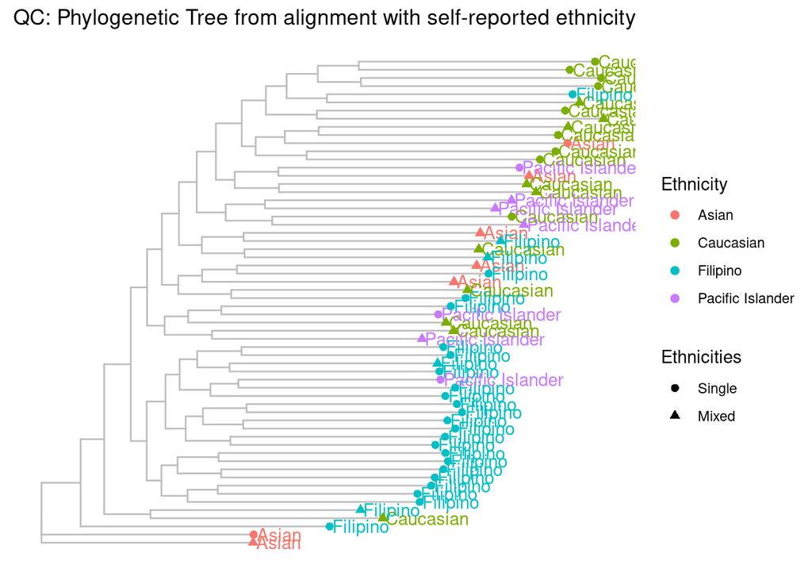

```r
clinical = pe.getClinicalInfo()
treePlot = clinical %>% mutate(Ethnicity = clinical$ethnicityCategory, Ethnicities = factor(mixed, labels = c("Single", "Mixed")))
treePlot$patientId = glue("Sample{treePlot$patientId}")
ggtree(tree, color = "grey") %<+% treePlot +
  geom_tiplab(aes(color=Ethnicity, label = Ethnicity), show.legend = FALSE) +
  geom_tippoint(size = 2, aes(color=Ethnicity, shape = Ethnicities), alpha=1) +
  labs(title = "QC: Phylogenetic Tree from alignment with self-reported ethnicity") +
  theme(legend.position="right")
```

```r
source("setup.r")
```

```
[1] "Notice: cache already initialized. Keeping existing cache."
```

```
[conflicted] Removing existing preference
```

```
[conflicted] Will prefer dplyr::filter over any other package
```

```r
library(Rtsne)
library(scatterplot3d)
library(rgl)
```

```r
clinical = pe.getClinicalInfo()
domRecMatrixNoInvariants = pe.getNumericAlleleMatrix()
tsne <- Rtsne(domRecMatrixNoInvariants, dims = 2, max_iter = 500, perplexity = 3)
```

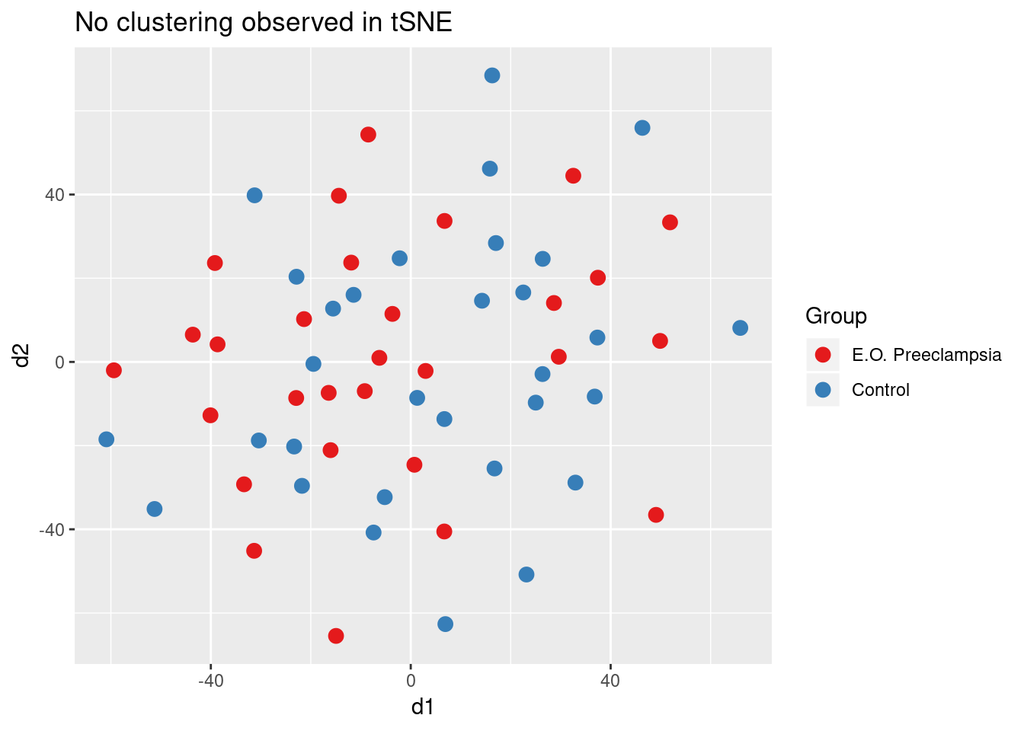

```r
df = data.frame(d1 = tsne$Y[,1], d2 = tsne$Y[,2], preeclampsia = clinical$preeclampsia)
ggplot(df, aes(x=d1, y=d2, color=as.factor(preeclampsia))) + geom_point(size = 3) +
  scale_color_manual(values = brewer.pal(n = 8, name = "Set1"), labels = c("E.O. Preeclampsia", "Control"), name = "Group") +
  labs(title = "No clustering observed in tSNE")
```

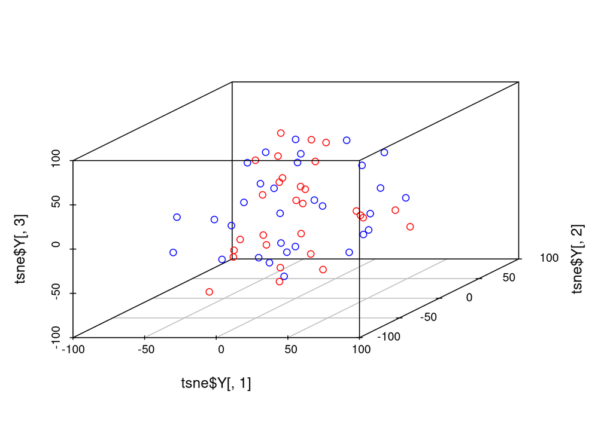

```r
# Let's try in 3D
tsne <- Rtsne(domRecMatrixNoInvariants, dims = 3, max_iter = 500, perplexity = 3)
scatterplot3d(x=tsne$Y[,1],y=tsne$Y[,2],z=tsne$Y[,3], color = c("red","blue")[clinical$preeclampsia + 1])
```

# Let’s try interactive CSV

```r
tsne <- Rtsne(domRecMatrixNoInvariants, dims = 3, max_iter = 500, perplexity = 3)
plot3d(x=tsne$Y[,1],y=tsne$Y[,2],z=tsne$Y[,3], col = c("red","blue")[clinical$preeclampsia + 1], type="s",radius=3)
```

# Let’s look at Ethnicity

```r
tsne <- Rtsne(domRecMatrixNoInvariants, dims = 3, max_iter = 500, perplexity = 3)
plot3d(x=tsne$Y[,1],y=tsne$Y[,2],z=tsne$Y[,3], col = c("red","blue", "green", "orange")[as.integer(clinical$ethnicityCategory)], type="s",radius=3)
```

```r
source("setup.r")
```

```
[1] "Notice: cache already initialized. Keeping existing cache."
```

```
[conflicted] Removing existing preference
```

```
[conflicted] Will prefer dplyr::filter over any other package
```

```r
snpdata <- pe.getSnpData()
head(snpdata)
```

|  | illuminaSnpLocation | sampleId | allele1 | allele2 | avgGenCallScore |
| --- | --- | --- | --- | --- | --- |
| 1 | chr1:109457160 | 2 | C | C | 0.8609 |
| 2 | chr1:109457233 | 2 | C | C | 0.7725 |
| 3 | chr1:109457614 | 2 | - | - | 0.0000 |
| 4 | chr1:109457618 | 2 | A | A | 0.5787 |
| 5 | chr1:109457943 | 2 | A | G | 0.8236 |
| 6 | chr1:109458224 | 2 | G | G | 0.8915 |

### Let’s look at the entire SNP data and see what we find

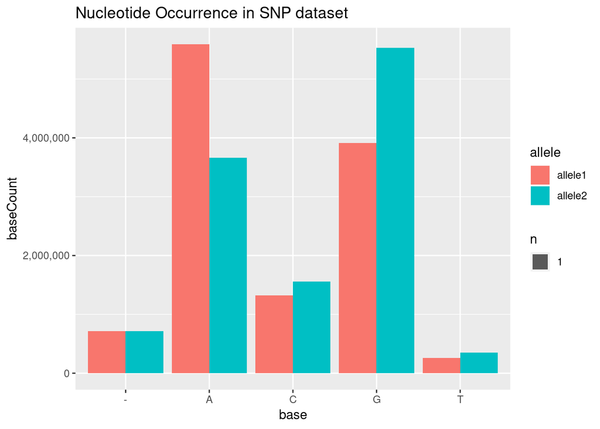

```r
allele1 = summary(as.factor(snpdata$allele1))
allele2 = summary(as.factor(snpdata$allele2))
res = data.frame(baseCount = allele1, allele = "allele1", base = names(allele1))
res2 = data.frame(baseCount = allele2, allele = "allele2", base = names(allele2))
sums = rbind(res, res2)
ggplot(sums, aes(x = base, fill = allele, y = baseCount)) + geom_bar(position = "dodge", stat = "sum") + labs(title = "Nucleotide Occurrence in SNP dataset") + scale_y_continuous(labels = comma)
```

```r
sums
```

|  | baseCount | allele | base |
| --- | --- | --- | --- |
| - | 714768 | allele1 | - |
| A | 5591025 | allele1 | A |
| C | 1323995 | allele1 | C |
| G | 3913339 | allele1 | G |
| T | 260373 | allele1 | T |
| -1 | 714768 | allele2 | - |
| A1 | 3658503 | allele2 | A |
| C1 | 1554787 | allele2 | C |
| G1 | 5527990 | allele2 | G |
| T1 | 347452 | allele2 | T |

### Is there any difference in base pair frequency amongst the samples?

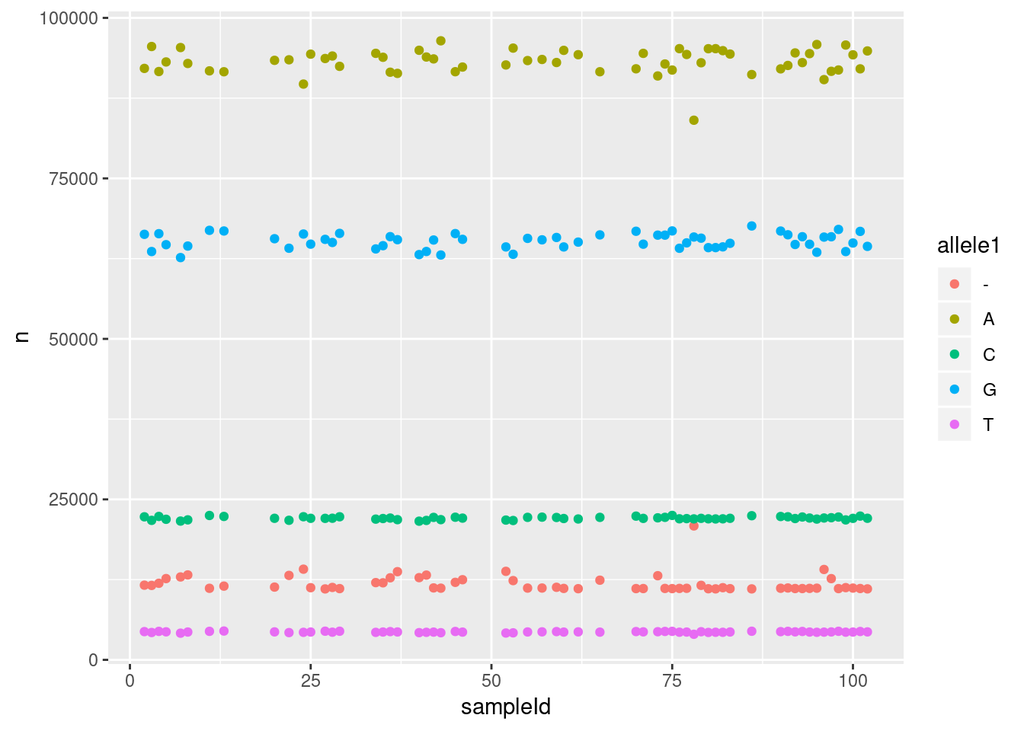

```r
bySample1 = snpdata %>% select(sampleId, allele1) %>% group_by(sampleId, allele1) %>% summarise(n = n())
ggplot(bySample1, aes(x = sampleId, y = n, color = allele1)) + geom_point()
```

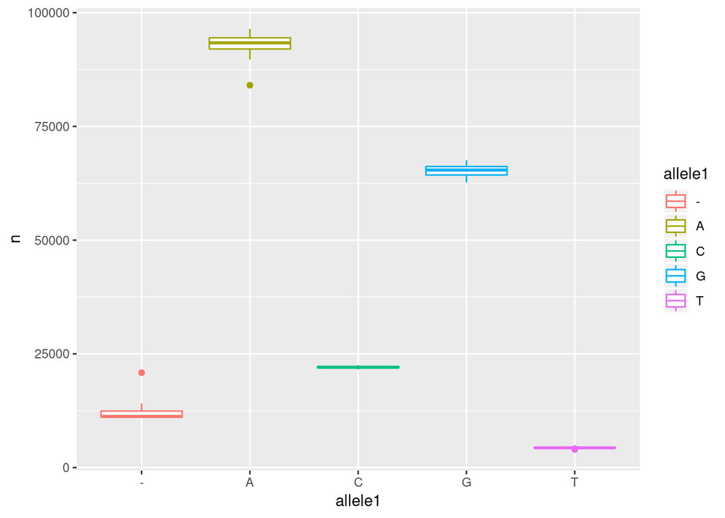

```r
ggplot(bySample1, aes(x = allele1, y = n, color = allele1)) + geom_boxplot()
```

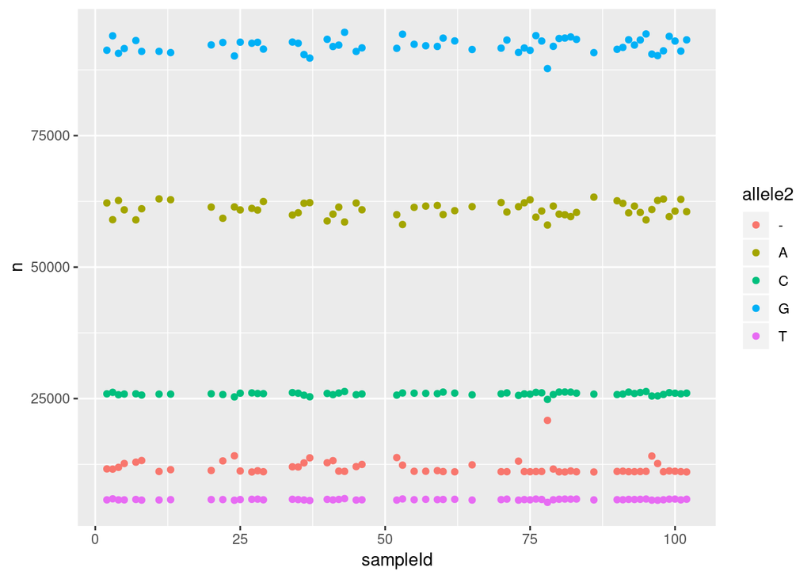

```r
bySample2 = snpdata %>% select(sampleId, allele2) %>% group_by(sampleId, allele2) %>% summarise(n = n())
ggplot(bySample2, aes(x = sampleId, y = n, color = allele2)) + geom_point()
```

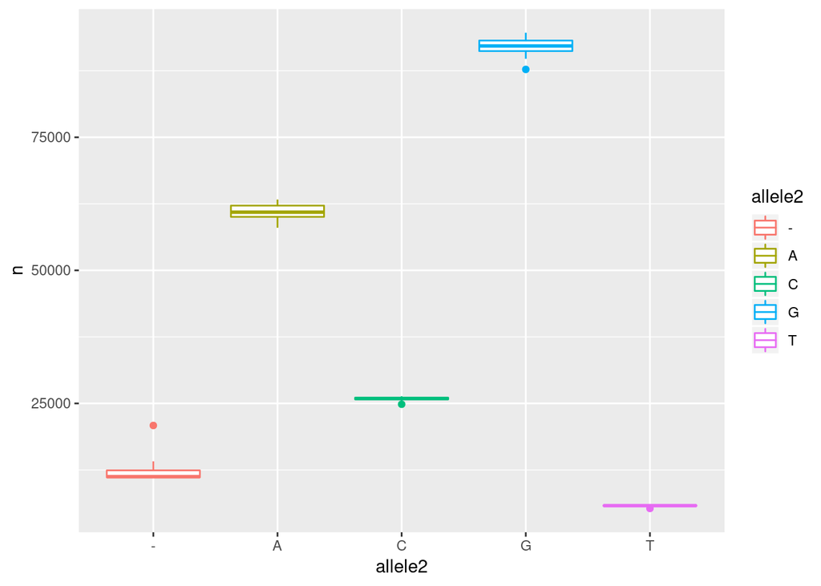

```r
ggplot(bySample2, aes(x = allele2, y = n, color = allele2)) + geom_boxplot()
```

## What are those outliers? Let’s look at the call rates

All of the outliers are with patient 78. Let’s see the avg gen call score by patient:

```r
# There are 8 values with a NaN for gencall score. We can set those to 0.0 because they are all uncalled bases ("--")..
snpdata[is.na(snpdata$avgGenCallScore),]["avgGenCallScore"] = 0
```

```r
scoresByPatient = snpdata %>% select(sampleId, avgGenCallScore) %>% group_by(sampleId) %>% summarise(average = mean(avgGenCallScore))
summary(scoresByPatient$average)
```

```
   Min. 1st Qu.  Median    Mean 3rd Qu.    Max.
 0.7245  0.7798  0.7892  0.7844  0.7903  0.7909
```

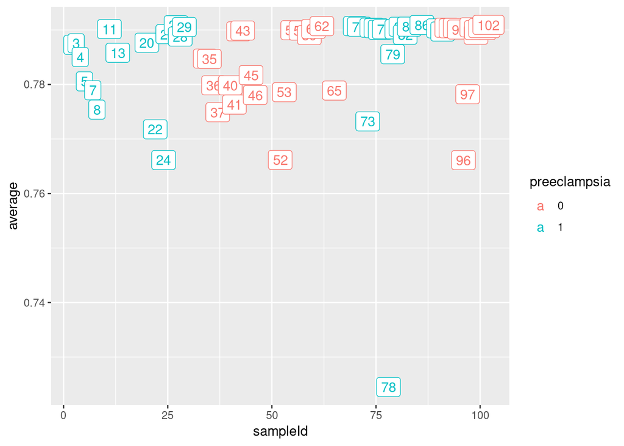

```r
scoresByPatient$preeclampsia = clinical %>% arrange(patientId) %>% select(preeclampsia) %>% unlist %>% as.factor
ggplot(scoresByPatient, aes(y = average, x = sampleId, color = preeclampsia)) + geom_point() + geom_label(aes(label = sampleId))
```

### Takeaways

- Patient 78 has low quality reads.

## Let’s make sure there are no noticeable difference in calls between the case and control groups

```r
a1 = snpdata %>% group_by(allele1, sampleId) %>% summarise(count = n()) %>% spread(allele1, count)
a2 = snpdata %>% group_by(allele2, sampleId) %>% summarise(count = n()) %>% spread(allele2, count) %>% select(-sampleId)
colnames(a2) = c("-2", "A2", "C2", "G2", "T2")
aBoth= cbind(a1, a2)
aBoth$preeclampsia = clinical$preeclampsia
aBoth = aBoth %>% select(-sampleId) %>% group_by(preeclampsia) %>% summarise_all(funs(mean))
aBoth
```

| preeclampsia | - | A | C | G | T | -2 | A2 | C2 | G2 | T2 |
| --- | --- | --- | --- | --- | --- | --- | --- | --- | --- | --- |
| 0 | 11889.93 | 93502.10 | 22026.90 | 64975.97 | 4330.103 | 11889.93 | 60798.48 | 25939.17 | 92297.72 | 5799.690 |
| 1 | 11934.19 | 92885.94 | 22103.71 | 65452.77 | 4348.387 | 11934.19 | 61140.23 | 25888.74 | 91979.23 | 5782.613 |

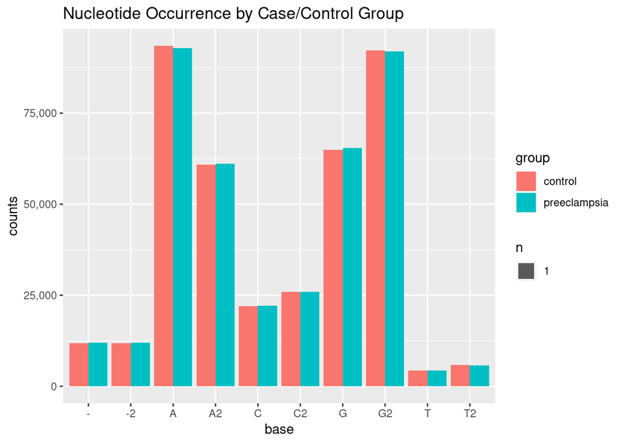

```r
aBoth2 = t(aBoth)
colnames(aBoth2) = c("control", "preeclampsia")
aBoth2 = as.data.frame(aBoth2)
aBoth2 = aBoth2[-1,]
aBoth2$base = unlist(rownames(aBoth2))
aBoth2 = aBoth2 %>% gather('control', 'preeclampsia', key = 'group', value = 'counts')
ggplot(aBoth2, aes(x = base, fill = group, y = counts)) + geom_bar(position = "dodge", stat = "sum") + labs(title = "Nucleotide Occurrence by Case/Control Group") + scale_y_continuous(labels = comma)
```

# Takeaway: No difference found.

# Let’s look at the variance in SNPS from both alleles combined

```r
simpleSNP = snpdata
simpleSNP$avgGenCallScore = NULL
simpleSNP = simpleSNP %>% unite(alleles, c(allele1, allele2), sep = "")
colnames(simpleSNP) = c("location", "sample", "alleles")
simpleSNP = simpleSNP %>% spread(sample, alleles, sep = "")
head(simpleSNP)
```

|  | location | sample2 | sample3 | sample4 | sample5 | sample7 | sample8 | sample11 | sample13 | sample20 | sample22 | sample24 | sample25 | sample27 | sample28 | sample29 | sample34 | sample35 | sample36 | sample37 | sample40 | sample41 | sample42 | sample43 | sample45 | sample46 | sample52 | sample53 | sample55 | … |
| --- | --- | --- | --- | --- | --- | --- | --- | --- | --- | --- | --- | --- | --- | --- | --- | --- | --- | --- | --- | --- | --- | --- | --- | --- | --- | --- | --- | --- | --- | --- |
| 1 | chr1_156842949 | AA | AA | AA | AA | AA | AA | AA | AA | AA | AA | AA | AA | AA | AA | AA | AA | AA | AA | AA | AA | AA | AA | AA | AA | AA | AA | AA | AA | … |
| 2 | chr1_156843018 | CC | CC | CC | CC | CC | CC | CC | CC | CC | CC | CC | CC | CC | CC | CC | CC | CC | CC | CC | CC | CC | CC | CC | CC | CC | CC | CC | CC | … |
| 3 | chr1_156843096 | GG | GG | GG | GG | GG | GG | GG | GG | GG | GG | GG | GG | GG | GG | GG | GG | GG | GG | GG | GG | GG | GG | GG | GG | GG | GG | GG | GG | … |
| 4 | chr1_156843336 | CC | CC | CC | CC | CC | CC | CC | CC | CC | CC | CC | CC | CC | CC | CC | CC | CC | CC | CC | CC | CC | CC | CC | CC | CC | CC | CC | CC | … |
| 5 | chr1_156843597 | AA | AA | AA | AA | AA | AA | AA | AA | AA | AA | AA | AA | AA | AA | AA | AA | AA | AA | AA | AA | AA | AA | AA | AA | AA | AA | AA | AA | … |
| 6 | chr1_156843616 | GG | GG | GG | GG | GG | GG | GG | GG | GG | GG | GG | GG | GG | GG | GG | GG | GG | GG | GG | GG | GG | GG | GG | GG | GG | GG | GG | GG | … |

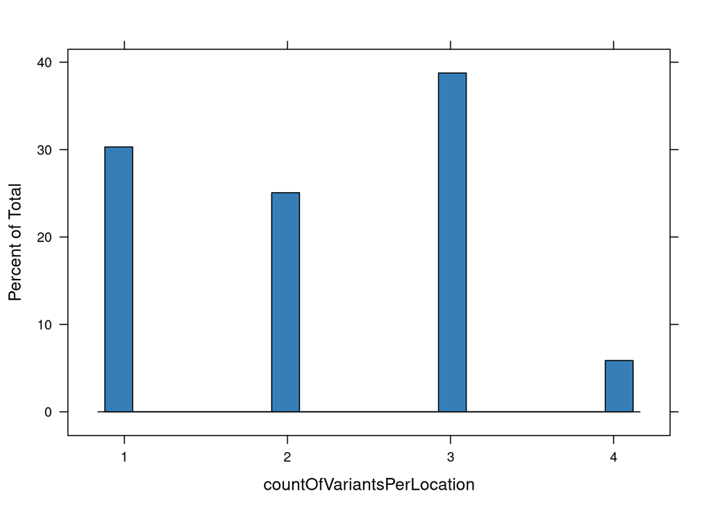

```r
countOfVariantsPerLocation <- apply(simpleSNP[,-1], 1, function(x)length(unique(x)))
histogram(countOfVariantsPerLocation, col=brewer.pal(n = 3, name = "Set1")[2])
```

```r
data.frame(countOfVariantsPerLocation = countOfVariantsPerLocation) %>% group_by(countOfVariantsPerLocation) %>% summarise(n=n())
```

| countOfVariantsPerLocation | n |
| --- | --- |
| 1 | 59608 |
| 2 | 49313 |
| 3 | 76254 |
| 4 | 11550 |

### So there is no variation in 60,000 of these locations.

### In 16 loci Illumina has 2 measurements

```r
duplicates = pe.getDuplicateMeasurementLocations()
duplicates
```

| Chr | MapInfo | id |
| --- | --- | --- |
| 1 | 120353869 | 1 120353869 |
| 1 | 120353869 | 1 120353869 |
| 11 | 2147527 | 11 2147527 |
| 11 | 2147527 | 11 2147527 |
| 11 | 2389540 | 11 2389540 |
| 11 | 2389540 | 11 2389540 |
| 11 | 61426522 | 11 61426522 |
| 11 | 61426522 | 11 61426522 |
| 11 | 71968277 | 11 71968277 |
| 11 | 71968277 | 11 71968277 |

[output cut: 22 more lines]

### Let’s see what’s happening at these spots and if it is safe to drop one set

```r
fullSet = pe.getSnpsWithChipInfo()
head(fullSet)
```

|  | illuminaSnpLocation | sampleId | allele1 | allele2 | avgGenCallScore | IlmnID | IlmnStrand | AddressA_ID | AlleleA_ProbeSeq | AddressB_ID | AlleleB_ProbeSeq | GenomeBuild | Chr | MapInfo | Source | SourceVersion | SourceStrand | SourceSeq | TopGenomicSeq | BeadSetID |
| --- | --- | --- | --- | --- | --- | --- | --- | --- | --- | --- | --- | --- | --- | --- | --- | --- | --- | --- | --- | --- |
| 1 | chr1:109457160 | 2 | C | C | 0.8609 | chr1:109457160-0_B_R_1602772855 | BOT | 41769450 | AGCCTTTTGTTAGGTGCGAGGGAGAAGGAAATTTCTGGGTCATCTTTCAG | NA | NA | 36 | 1 | 109457160 | 1000 Genomes | 0 | TOP | AAAAGTGCTGGCTGCTCACCATCAGGACTTCTGCAAAAGACTTCAGTTGAGGAAAGAAGT[A/C]CTGAAAGATGACCCAGAAATTTCCTTCTCCCTCGCACCTAACAAAAGGCTTTCAAAGCCA | AAAAGTGCTGGCTGCTCACCATCAGGACTTCTGCAAAAGACTTCAGTTGAGGAAAGAAGT[A/C]CTGAAAGATGACCCAGAAATTTCCTTCTCCCTCGCACCTAACAAAAGGCTTTCAAAGCCA | 225 |
| 2 | chr1:109457233 | 2 | C | C | 0.7725 | chr1:109457233-0_B_F_1602777793 | BOT | 11615356 | CCTTCTCCCTCGCACCTAACAAAAGGCTTTCAAAGCCATGAGAGAATGAG | NA | NA | 36 | 1 | 109457233 | 1000 Genomes | 0 | BOT | CCAGAAATTTCCTTCTCCCTCGCACCTAACAAAAGGCTTTCAAAGCCATGAGAGAATGAG[T/G]ATGTCAAGAGACCAAAGAGGGCCGGGCGCGGTGGTTCACGCCTGTAATCTCAGCACTTTG | CAAAGTGCTGAGATTACAGGCGTGAACCACCGCGCCCGGCCCTCTTTGGTCTCTTGACAT[A/C]CTCATTCTCTCATGGCTTTGAAAGCCTTTTGTTAGGTGCGAGGGAGAAGGAAATTTCTGG | 225 |
| 3 | chr1:109457614 | 2 | - | - | 0.0000 | chr1:109457614-0_B_R_1601092847 | BOT | 39606509 | TTAAGCGAGGAGTTTGCCTTAGCCGCAATTTCCCAAGCGCCGCACGTGGG | NA | NA | 36 | 1 | 109457614 | 1000 Genoms | 0 | TOP | AGAGAGAAAGAGAGAGAGAGAGAGAGAGAGAGAGAGAGAGAGAGAGAGAGAGAGAGAGAG[A/G]CCCACGTGCGGCGCTTGGGAAATTGCGGCTAAGGCAAACTCCTCGCTTAAACTCGGATCA | AGAGAGAAAGAGAGAGAGAGAGAGAGAGAGAGAGAGAGAGAGAGAGAGAGAGAGAGAGAG[A/G]CCCACGTGCGGCGCTTGGGAAATTGCGGCTAAGGCAAACTCCTCGCTTAAACTCGGATCA | 225 |
| 4 | chr1:109457618 | 2 | A | A | 0.5787 | chr1:109457618-0_B_R_1601092821 | BOT | 44757451 | GAGTTTAAGCGAGGAGTTTGCCTTAGCCGCAATTTCCCAAGCGCCGCACG | NA | NA | 36 | 1 | 109457618 | 1000 Genoms | 0 | TOP | AGAAAGAGAGAGAGAGAGAGAGAGAGAGAGAGAGAGAGAGAGAGAGAGAGAGAGAGGCCC[A/G]CGTGCGGCGCTTGGGAAATTGCGGCTAAGGCAAACTCCTCGCTTAAACTCGGATCAACTA | AGAAAGAGAGAGAGAGAGAGAGAGAGAGAGAGAGAGAGAGAGAGAGAGAGAGAGAGGCCC[A/G]CGTGCGGCGCTTGGGAAATTGCGGCTAAGGCAAACTCCTCGCTTAAACTCGGATCAACTA | 225 |
| 5 | chr1:109457943 | 2 | A | G | 0.8236 | chr1:109457943-0_B_F_1602595859 | BOT | 63682436 | AGGGCAGTAGAAAACGGAAATTTGTTGGCTGGCTTGGAGGATGCTTCCAC | NA | NA | 36 | 1 | 109457943 | 1000 Genomes | 0 | BOT | CTGGCCCGAAAGGGCAGTAGAAAACGGAAATTTGTTGGCTGGCTTGGAGGATGCTTCCAC[T/C]GTGTTCTTCACACGAGCCCCGGGCCTGCCTGTTGGGCCGGTTGCGCACCCCGGGCGCGCG | CGCGCGCCCGGGGTGCGCAACCGGCCCAACAGGCAGGCCCGGGGCTCGTGTGAAGAACAC[A/G]GTGGAAGCATCCTCCAAGCCAGCCAACAAATTTCCGTTTTCTACTGCCCTTTCGGGCCAG | 225 |
| 6 | chr1:109458224 | 2 | G | G | 0.8915 | chr1:109458224-0_T_R_1602652468 | TOP | 62754380 | TGCTGGCAGAAGGCGGAAAAAAAGGGGAGGGAGGTACACAGGCGGAGGAT | NA | NA | 36 | 1 | 109458224 | 1000 Genomes | 0 | BOT | GAAGGATGGGCGGTGTTGGCGTAGCCGCAGGGAGGTGACTGAAGCGAGCCTGGCCTCTTG[T/C]ATCCTCCGCCTGTGTACCTCCCTCCCCTTTTTTTCCGCCTTCTGCCAGCAGAAGCAGCAG | CTGCTGCTTCTGCTGGCAGAAGGCGGAAAAAAAGGGGAGGGAGGTACACAGGCGGAGGAT[A/G]CAAGAGGCCAGGCTCGCTTCAGTCACCTCCCTGCGGCTACGCCAACACCGCCCATCCTTC | 225 |

```r
dupeMeasurements = fullSet %>% select(sampleId, allele1, allele2, Chr, MapInfo) %>% mutate(id = paste(Chr, MapInfo)) %>% filter(id %in% duplicates$id)
dupeMeasurements[1:5,]
```

|  | sampleId | allele1 | allele2 | Chr | MapInfo | id |
| --- | --- | --- | --- | --- | --- | --- |
| 1 | 2 | - | - | 1 | 120353869 | 1 120353869 |
| 2 | 2 | A | G | 11 | 61426522 | 11 61426522 |
| 3 | 2 | A | G | 2 | 169538574 | 2 169538574 |
| 4 | 2 | G | G | 2 | 27584444 | 2 27584444 |
| 5 | 2 | A | G | 22 | 35792882 | 22 35792882 |

### Takeaway

There is variation at these SNPs. We’ll need to think about how to handle

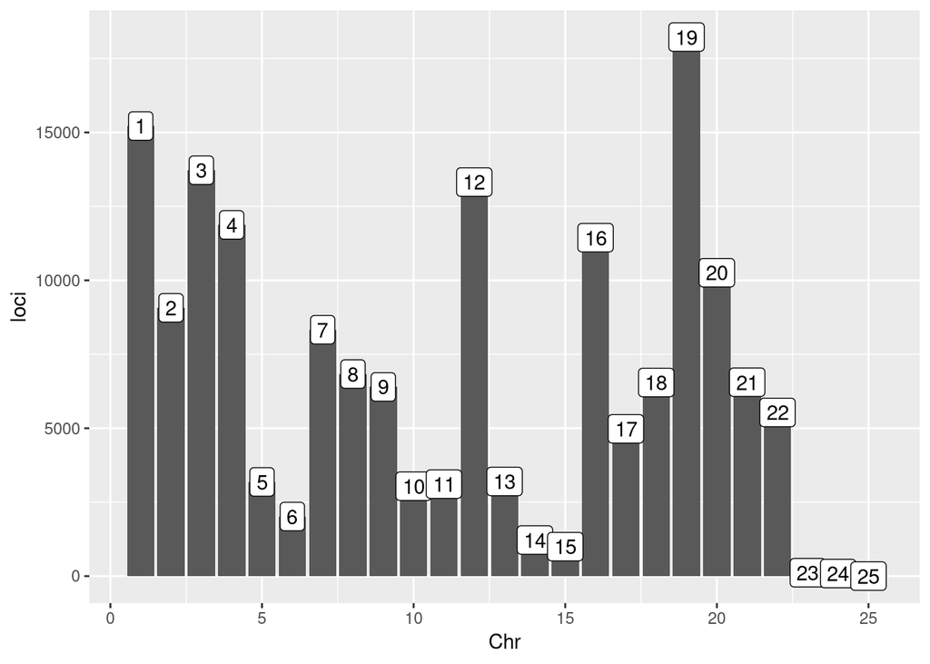

```r
phyloSnp = pe.getSimpleSNPFormatForPhyloTree()
chrData = phyloSnp %>% group_by(`#Chrom`) %>% summarise(loci = n()) %>% mutate(Chr = 1:25) %>% arrange(Chr)
ggplot(chrData, aes(x = Chr, y = loci, label  = `#Chrom`)) + geom_col() + geom_label()
```

```r
chrData
```

| #Chrom | loci | Chr |
| --- | --- | --- |
| 1 | 15218 | 1 |
| 2 | 9071 | 2 |
| 3 | 13723 | 3 |
| 4 | 11876 | 4 |
| 5 | 3185 | 5 |
| 6 | 2016 | 6 |
| 7 | 8329 | 7 |
| 8 | 6832 | 8 |
| 9 | 6396 | 9 |
| 10 | 3040 | 10 |

[output cut: 15 more lines]

### Takeaway

We confirm there are no Y chromosome measurements made.

## Let’s see how often the variations vary for each allele

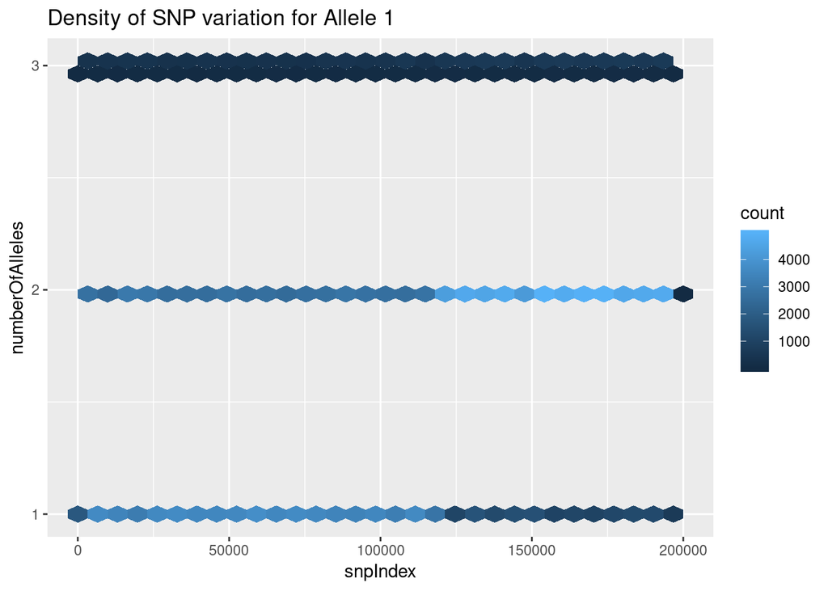

```r
alleleCounts = snpdata %>% select(illuminaSnpLocation, allele1) %>% group_by(illuminaSnpLocation) %>% summarise(numberOfAlleles = length(unique(allele1)))
alleleCounts$snpIndex = seq.int(nrow(alleleCounts))
ggplot(alleleCounts, aes(x = snpIndex, y = numberOfAlleles)) + geom_hex( bins = 30) + scale_y_continuous(breaks = c(1,2,3)) + labs(title = "Density of SNP variation for Allele 1")
```

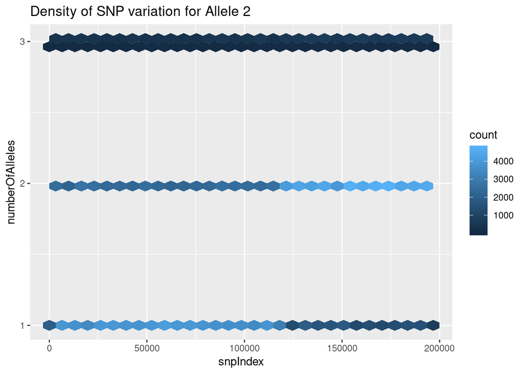

```r
alleleCounts = snpdata %>% select(illuminaSnpLocation, allele2) %>% group_by(illuminaSnpLocation) %>% summarise(numberOfAlleles = length(unique(allele2)))
alleleCounts$snpIndex = seq.int(nrow(alleleCounts))
ggplot(alleleCounts, aes(x = snpIndex, y = numberOfAlleles)) + geom_hex( bins = 30) + scale_y_continuous(breaks = c(1,2,3)) + labs(title = "Density of SNP variation for Allele 2")
```

# Let’s see why we have more than 2 nucleotides found in a base pair

```r
alleles1 = snpdata %>% mutate(allele = allele1) %>% select(illuminaSnpLocation, allele) %>%
  group_by(illuminaSnpLocation) %>% mutate(allele = paste(unique(allele), collapse = "")) %>%
  group_by(allele) %>% summarise(count = n()) %>% mutate(len = str_length(allele), count = count/60) %>%
  arrange(desc(len)) %>% select(count, allele)


alleles2 = snpdata %>% mutate(allele = allele2) %>% select(illuminaSnpLocation, allele) %>%
  group_by(illuminaSnpLocation) %>% mutate(allele = paste(unique(allele), collapse = "")) %>%
  group_by(allele) %>% summarise(count = n()) %>% mutate(len = str_length(allele), count = count/60) %>%
  arrange(desc(len)) %>% select(count, allele)

both = cbind(alleles1, alleles2[-2])
colnames(both) = c("allele1count", "nucleotides", "allele2count")
both
```

| allele1count | nucleotides | allele2count |
| --- | --- | --- |
| 64 | -AC | 24 |
| 229 | -AG | 100 |
| 10 | -AT | 7 |
| 24 | -CA | 65 |
| 23 | -CG | 12 |
| 111 | -GA | 220 |
| 6 | -GC | 19 |
| 6 | -TA | 11 |
| 363 | A-C | 169 |
| 1128 | A-G | 517 |

[output cut: 35 more lines]

### Takeaway: 3rd read is just noncalls.

```r
source("setup.r")
```

```
[1] "Notice: cache already initialized. Keeping existing cache."
```

```
[conflicted] Removing existing preference
```

```
[conflicted] Will prefer dplyr::filter over any other package
```

## Some notes about this Illumina Dataset

The data comes from the following:

```
Illumina
Descriptor File Name: Cardio-Metabo_Chip_11395247_A.bpm
Assay Format: Infinium HD Ultra
Date Manufactured: 9/8/2009
Loci Count: 196725
```

```r
# Let's look at the raw illumina data about this metabochip
file.head(pe.illuminaPath, 10)
```

```
Illumina, Inc.,,,,,,,,,,,,,,,,,
[Heading],,,,,,,,,,,,,,,,,,
Descriptor File Name,Cardio-Metabo_Chip_11395247_A.bpm,,,,,,,,,,,,,,,,,
Assay Format,Infinium HD Ultra,,,,,,,,,,,,,,,,,
Date Manufactured,9/8/2009,,,,,,,,,,,,,,,,,
Loci Count ,196725,,,,,,,,,,,,,,,,,
[Assay],,,,,,,,,,,,,,,,,,
IlmnID,Name,IlmnStrand,SNP,AddressA_ID,AlleleA_ProbeSeq,AddressB_ID,Allele
chr1:109457160-0_B_R_1602772855,chr1:109457160,BOT,[T/G],41769450,AGCCTTTT
chr1:109457233-0_B_F_1602777793,chr1:109457233,BOT,[T/G],11615356,CCTTCTCC
```

```r
metaboChip = pe.getMetaboChip()
head(metaboChip)
```

| IlmnID | Name | IlmnStrand | SNP | AddressA_ID | AlleleA_ProbeSeq | AddressB_ID | AlleleB_ProbeSeq | GenomeBuild | Chr | MapInfo | Ploidy | Species | Source | SourceVersion | SourceStrand | SourceSeq | TopGenomicSeq | BeadSetID |
| --- | --- | --- | --- | --- | --- | --- | --- | --- | --- | --- | --- | --- | --- | --- | --- | --- | --- | --- |
| chr1:109457160-0_B_R_1602772855 | chr1:109457160 | BOT | [T/G] | 41769450 | AGCCTTTTGTTAGGTGCGAGGGAGAAGGAAATTTCTGGGTCATCTTTCAG | NA | NA | 36 | 1 | 109457160 | diploid | Homo sapiens | 1000 Genomes | 0 | TOP | AAAAGTGCTGGCTGCTCACCATCAGGACTTCTGCAAAAGACTTCAGTTGAGGAAAGAAGT[A/C]CTGAAAGATGACCCAGAAATTTCCTTCTCCCTCGCACCTAACAAAAGGCTTTCAAAGCCA | AAAAGTGCTGGCTGCTCACCATCAGGACTTCTGCAAAAGACTTCAGTTGAGGAAAGAAGT[A/C]CTGAAAGATGACCCAGAAATTTCCTTCTCCCTCGCACCTAACAAAAGGCTTTCAAAGCCA | 225 |
| chr1:109457233-0_B_F_1602777793 | chr1:109457233 | BOT | [T/G] | 11615356 | CCTTCTCCCTCGCACCTAACAAAAGGCTTTCAAAGCCATGAGAGAATGAG | NA | NA | 36 | 1 | 109457233 | diploid | Homo sapiens | 1000 Genomes | 0 | BOT | CCAGAAATTTCCTTCTCCCTCGCACCTAACAAAAGGCTTTCAAAGCCATGAGAGAATGAG[T/G]ATGTCAAGAGACCAAAGAGGGCCGGGCGCGGTGGTTCACGCCTGTAATCTCAGCACTTTG | CAAAGTGCTGAGATTACAGGCGTGAACCACCGCGCCCGGCCCTCTTTGGTCTCTTGACAT[A/C]CTCATTCTCTCATGGCTTTGAAAGCCTTTTGTTAGGTGCGAGGGAGAAGGAAATTTCTGG | 225 |
| chr1:109457614-0_B_R_1601092847 | chr1:109457614 | BOT | [T/C] | 39606509 | TTAAGCGAGGAGTTTGCCTTAGCCGCAATTTCCCAAGCGCCGCACGTGGG | NA | NA | 36 | 1 | 109457614 | diploid | Homo sapiens | 1000 Genoms | 0 | TOP | AGAGAGAAAGAGAGAGAGAGAGAGAGAGAGAGAGAGAGAGAGAGAGAGAGAGAGAGAGAG[A/G]CCCACGTGCGGCGCTTGGGAAATTGCGGCTAAGGCAAACTCCTCGCTTAAACTCGGATCA | AGAGAGAAAGAGAGAGAGAGAGAGAGAGAGAGAGAGAGAGAGAGAGAGAGAGAGAGAGAG[A/G]CCCACGTGCGGCGCTTGGGAAATTGCGGCTAAGGCAAACTCCTCGCTTAAACTCGGATCA | 225 |
| chr1:109457618-0_B_R_1601092821 | chr1:109457618 | BOT | [T/C] | 44757451 | GAGTTTAAGCGAGGAGTTTGCCTTAGCCGCAATTTCCCAAGCGCCGCACG | NA | NA | 36 | 1 | 109457618 | diploid | Homo sapiens | 1000 Genoms | 0 | TOP | AGAAAGAGAGAGAGAGAGAGAGAGAGAGAGAGAGAGAGAGAGAGAGAGAGAGAGAGGCCC[A/G]CGTGCGGCGCTTGGGAAATTGCGGCTAAGGCAAACTCCTCGCTTAAACTCGGATCAACTA | AGAAAGAGAGAGAGAGAGAGAGAGAGAGAGAGAGAGAGAGAGAGAGAGAGAGAGAGGCCC[A/G]CGTGCGGCGCTTGGGAAATTGCGGCTAAGGCAAACTCCTCGCTTAAACTCGGATCAACTA | 225 |
| chr1:109457943-0_B_F_1602595859 | chr1:109457943 | BOT | [T/C] | 63682436 | AGGGCAGTAGAAAACGGAAATTTGTTGGCTGGCTTGGAGGATGCTTCCAC | NA | NA | 36 | 1 | 109457943 | diploid | Homo sapiens | 1000 Genomes | 0 | BOT | CTGGCCCGAAAGGGCAGTAGAAAACGGAAATTTGTTGGCTGGCTTGGAGGATGCTTCCAC[T/C]GTGTTCTTCACACGAGCCCCGGGCCTGCCTGTTGGGCCGGTTGCGCACCCCGGGCGCGCG | CGCGCGCCCGGGGTGCGCAACCGGCCCAACAGGCAGGCCCGGGGCTCGTGTGAAGAACAC[A/G]GTGGAAGCATCCTCCAAGCCAGCCAACAAATTTCCGTTTTCTACTGCCCTTTCGGGCCAG | 225 |
| chr1:109458224-0_T_R_1602652468 | chr1:109458224 | TOP | [A/G] | 62754380 | TGCTGGCAGAAGGCGGAAAAAAAGGGGAGGGAGGTACACAGGCGGAGGAT | NA | NA | 36 | 1 | 109458224 | diploid | Homo sapiens | 1000 Genomes | 0 | BOT | GAAGGATGGGCGGTGTTGGCGTAGCCGCAGGGAGGTGACTGAAGCGAGCCTGGCCTCTTG[T/C]ATCCTCCGCCTGTGTACCTCCCTCCCCTTTTTTTCCGCCTTCTGCCAGCAGAAGCAGCAG | CTGCTGCTTCTGCTGGCAGAAGGCGGAAAAAAAGGGGAGGGAGGTACACAGGCGGAGGAT[A/G]CAAGAGGCCAGGCTCGCTTCAGTCACCTCCCTGCGGCTACGCCAACACCGCCCATCCTTC | 225 |

```r
skim_tee(metaboChip)
```

```
Skim summary statistics
 n obs: 196725
 n variables: 19

── Variable type:character ──────────────────────────────────────────────────────────────────────────────────────────────────────────────────────────────
         variable missing complete      n min max empty n_unique
 AlleleA_ProbeSeq       0   196725 196725  50  50     0   196701
 AlleleB_ProbeSeq  173712    23013 196725  50  50     0    23009
           IlmnID       0   196725 196725  23  36     0   196725
       IlmnStrand       0   196725 196725   3   3     0        2
             Name       0   196725 196725   5  17     0   196725
           Ploidy       0   196725 196725   7   7     0        1
              SNP       0   196725 196725   5   5     0       10
           Source       0   196725 196725   7  23     0        7
        SourceSeq       0   196725 196725  59 125     0   196711
     SourceStrand       0   196725 196725   3   3     0        2
          Species       0   196725 196725  12  12     0        1
    TopGenomicSeq       0   196725 196725  59 125     0   196705

── Variable type:factor ─────────────────────────────────────────────────────────────────────────────────────────────────────────────────────────────────
 variable missing complete      n n_unique
      Chr       0   196725 196725       26
                              top_counts ordered
 6: 21966, 1: 18720, 11: 16108, 2: 15750   FALSE

── Variable type:integer ────────────────────────────────────────────────────────────────────────────────────────────────────────────────────────────────
      variable missing complete      n        mean       sd        p0
   AddressA_ID       0   196725 196725 4e+07        1.8e+07   1.1e+07
   AddressB_ID  173712    23013 196725     4.2e+07  1.9e+07   1.1e+07
     BeadSetID       0   196725 196725   224.28     0.96    223
   GenomeBuild       0   196725 196725    35.88     1.44     18
       MapInfo       0   196725 196725     7.3e+07  5.5e+07 923
 SourceVersion       0   196725 196725    52.49    71.59      0
       p25         p50       p75      p100     hist
   2.5e+07     3.9e+07   5.5e+07   7.5e+07 ▇▇▇▇▇▆▅▆
   2.6e+07     4.2e+07   5.8e+07   7.5e+07 ▇▇▇▇▇▇▇▇
 223         225       225       225       ▅▁▁▁▁▁▁▇
  36          36        36        92       ▁▇▁▁▁▁▁▁
   2.8e+07 6e+07         1.1e+08   2.5e+08 ▇▆▅▅▂▂▁▁
   0           0       128       978       ▇▅▁▁▁▁▁▁
```

# Let’s attempt to build a model that can predict EO Preeclampsia from SNP data alone (spoiler alert: no success)

```r
source("setup.r")
```

```
[1] "Notice: cache already initialized. Keeping existing cache."
```

```
[conflicted] Removing existing preference
```

```
[conflicted] Will prefer dplyr::filter over any other package
```

```r
library(xgboost)
library(caTools)
conflict_prefer("union", "dplyr")
```

```
[conflicted] Will prefer dplyr::union over any other package
```

```r
conflict_prefer("colnames", "base")
```

```
[conflicted] Will prefer base::colnames over any other package
```

```r
conflict_prefer("as.numeric", "base")
```

```
[conflicted] Will prefer base::as.numeric over any other package
```

```r
clinical = pe.getClinicalInfo()
domRecMatrix = pe.getNumericAlleleMatrix()
domRecMatrix[1:5,1:5]
```

```
     chr1_156843624 chr1_156843733 chr1_156850715 chr1_156853992
[1,]              1             -1              1              1
[2,]              1              1              0              1
[3,]              1              1              0              1
[4,]              1              1              0              1
[5,]              1              1              1              1
     chr1_156854468
[1,]              1
[2,]              1
[3,]              1
[4,]              1
[5,]              1
```

```r
draw_confusion_matrix <- function(cm) {

  total = sum(cm$table)
  res <- as.numeric(cm$table)

  # Generate color gradients. Palettes come from RColorBrewer.
  greenPalette = c("#F7FCF5","#E5F5E0","#C7E9C0","#A1D99B","#74C476","#41AB5D","#238B45","#006D2C","#00441B")
  redPalette = c("#FFF5F0","#FEE0D2","#FCBBA1","#FC9272","#FB6A4A","#EF3B2C","#CB181D","#A50F15","#67000D")
  getColor = function (greenOrRed = "green", amount = 0) {
    if (amount == 0)
      return("#FFFFFF")
    palette = greenPalette
    if (greenOrRed == "red")
      palette = redPalette
    colorRampPalette(palette)(100)[10 + ceiling(90 * amount / total)]
  }

  # set the basic layout
  layout(matrix(c(1,1,2)))
  par(mar=c(2,2,2,2))
  plot(c(100, 345), c(300, 450), type = "n", xlab="", ylab="", xaxt='n', yaxt='n')
  title('CONFUSION MATRIX', cex.main=2)

  # create the matrix
  classes = colnames(cm$table)
  rect(150, 430, 240, 370, col=getColor("green", res[1]))
  text(195, 435, classes[1], cex=1.2)
  rect(250, 430, 340, 370, col=getColor("red", res[3]))
  text(295, 435, classes[2], cex=1.2)
  text(125, 370, 'Predicted', cex=1.3, srt=90, font=2)
  text(245, 450, 'Actual', cex=1.3, font=2)
  rect(150, 305, 240, 365, col=getColor("red", res[2]))
  rect(250, 305, 340, 365, col=getColor("green", res[4]))
  text(140, 400, classes[1], cex=1.2, srt=90)
  text(140, 335, classes[2], cex=1.2, srt=90)

  # add in the cm results
  text(195, 400, res[1], cex=1.6, font=2, col='white')
  text(195, 335, res[2], cex=1.6, font=2, col='white')
  text(295, 400, res[3], cex=1.6, font=2, col='white')
  text(295, 335, res[4], cex=1.6, font=2, col='white')

  # add in the specifics
  plot(c(100, 0), c(100, 0), type = "n", xlab="", ylab="", main = "DETAILS", xaxt='n', yaxt='n')
  text(10, 85, names(cm$byClass[1]), cex=1.2, font=2)
  text(10, 70, round(as.numeric(cm$byClass[1]), 3), cex=1.2)
  text(30, 85, names(cm$byClass[2]), cex=1.2, font=2)
  text(30, 70, round(as.numeric(cm$byClass[2]), 3), cex=1.2)
  text(50, 85, names(cm$byClass[5]), cex=1.2, font=2)
  text(50, 70, round(as.numeric(cm$byClass[5]), 3), cex=1.2)
  text(70, 85, names(cm$byClass[6]), cex=1.2, font=2)
  text(70, 70, round(as.numeric(cm$byClass[6]), 3), cex=1.2)
  text(90, 85, names(cm$byClass[7]), cex=1.2, font=2)
  text(90, 70, round(as.numeric(cm$byClass[7]), 3), cex=1.2)

  # add in the accuracy information
  text(30, 35, names(cm$overall[1]), cex=1.5, font=2)
  text(30, 20, round(as.numeric(cm$overall[1]), 3), cex=1.4)
  text(70, 35, names(cm$overall[2]), cex=1.5, font=2)
  text(70, 20, round(as.numeric(cm$overall[2]), 3), cex=1.4)
}
```

```r
combined = cbind(clinical %>% select(preeclampsia), domRecMatrix)
combined$preeclampsia = as.factor(combined$preeclampsia)

split <- sample.split(clinical$preeclampsia, SplitRatio = 0.8)
training_set = subset(combined, split == TRUE)
validation_set = subset(combined, split == FALSE)

dTrain <- xgb.DMatrix(as.matrix(training_set[-1]), label = as.matrix(training_set[1]))
dValidation <- xgb.DMatrix(as.matrix(validation_set[-1]), label = as.matrix(validation_set[1]))
dwatchlist <- list(eval = dValidation, train = dTrain)

params <- list(eta = 0.1, max_depth = 2,  objective = "binary:logistic")
classifier <- xgb.train(data = dTrain, params = params, save_period = 100, watchlist = dwatchlist,
  label = training_set[1], early_stopping_rounds = 5, nrounds = 50)
```

[output not shown]

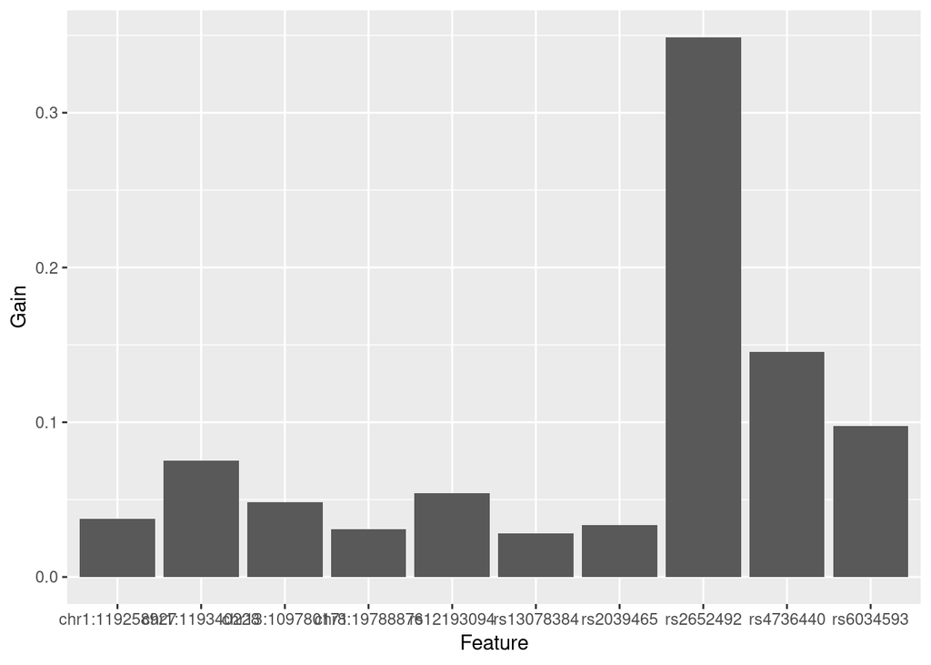

```r
y_pred <- predict(classifier, newdata = as.matrix(validation_set[-1])) %>%  round

actual = as.data.frame(validation_set)[, 1]
importance = xgb.importance(colnames(combined)[-1], model = classifier)
ggplot(importance[1:10,], aes(x = Feature, y = Gain)) + geom_col()
```

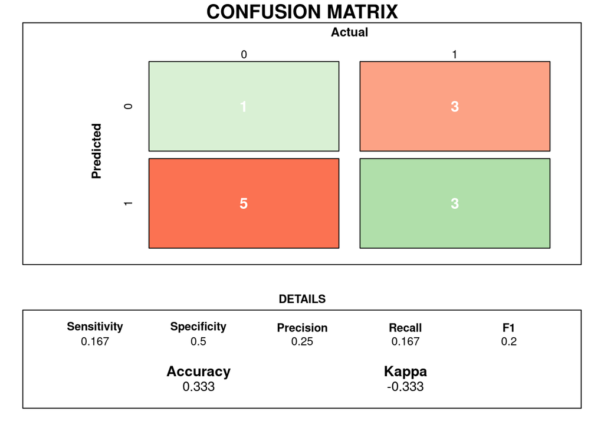

```r
cm = caret::confusionMatrix(factor(y_pred), factor(actual))
draw_confusion_matrix(cm)
```

```r
print(importance[1:10,])
```

```
            Feature       Gain      Cover  Frequency
 1:       rs2652492 0.34887673 0.33553125 0.22222222
 2:       rs4736440 0.14551246 0.16446875 0.11111111
 3:       rs6034593 0.09757756 0.08659054 0.11111111
 4:  chr1:119340228 0.07513690 0.06663553 0.07407407
 5:      rs12193094 0.05426129 0.02975212 0.03703704
 6: chr13:109780171 0.04842820 0.02975212 0.03703704
 7:  chr1:119258927 0.03764861 0.02956836 0.03703704
 8:       rs2039465 0.03372908 0.03306453 0.03703704
 9:   chr8:19788876 0.03069535 0.02866063 0.03703704
10:      rs13078384 0.02808678 0.02793489 0.03703704
```

```r
cm
```

```
Confusion Matrix and Statistics

          Reference
Prediction 0 1
         0 1 3
         1 5 3

               Accuracy : 0.3333
                 95% CI : (0.0992, 0.6511)
    No Information Rate : 0.5
    P-Value [Acc > NIR] : 0.9270

                  Kappa : -0.3333
 Mcnemar's Test P-Value : 0.7237

            Sensitivity : 0.16667
            Specificity : 0.50000
         Pos Pred Value : 0.25000
         Neg Pred Value : 0.37500
             Prevalence : 0.50000
         Detection Rate : 0.08333
   Detection Prevalence : 0.33333
      Balanced Accuracy : 0.33333

       'Positive' Class : 0
```

# Try cross validation

```r
clinical = pe.getClinicalInfo()
domRecMatrix = pe.getNumericAlleleMatrix()
params <- list(eta = 0.02, max_depth = 2,  objective = "binary:logistic")
booster = xgb.cv(params, domRecMatrix, 30, nfold = 5, label = clinical$preeclampsia)
booster$evaluation_log[booster$best_iteration]$test_error_mean
```

[output not shown]

# Let’s try to predict EOPE on clinical data as a sanity check. We expect 0 error/100% accuracy.

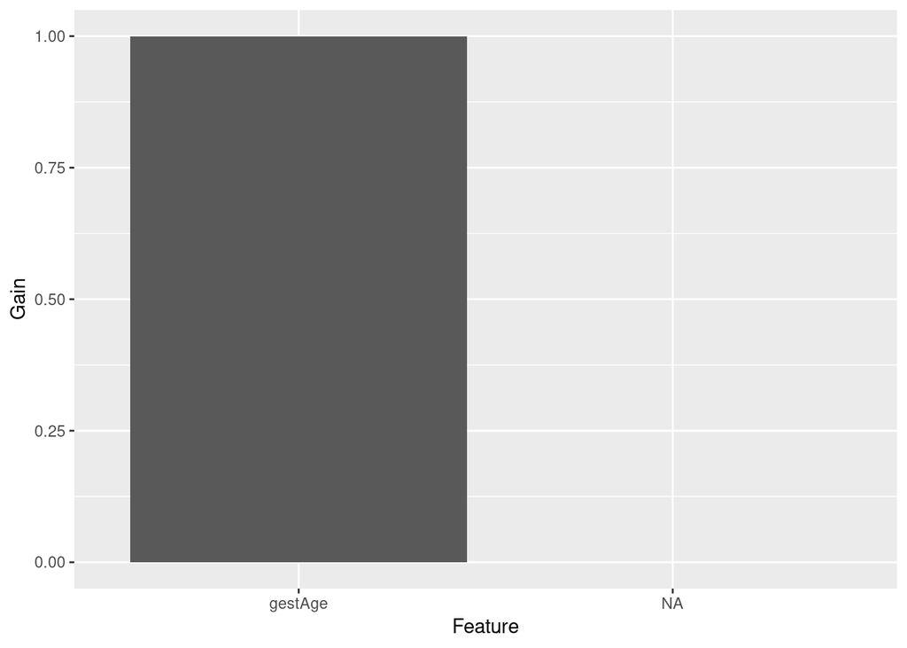

```r
clinicalNumeric = as.matrix(pe.getClinicalAsNumerics())
training_set = subset(clinicalNumeric, split == TRUE)
validation_set = subset(clinicalNumeric, split == FALSE)
dTrain <- xgb.DMatrix(training_set[,-1], label = training_set[,1])

params <- list(eta = 0.3, max_depth = 1, objective = "binary:logistic")
classifier <- xgb.train(params, dTrain, 20)

y_pred <- predict(classifier, newdata = validation_set[,-1]) %>% round

actual = as.data.frame(validation_set)[, 1]
importance = xgb.importance(colnames(clinicalNumeric)[-1], model = classifier)
ggplot(importance[1:10,], aes(x = Feature, y = Gain)) + geom_col()
```

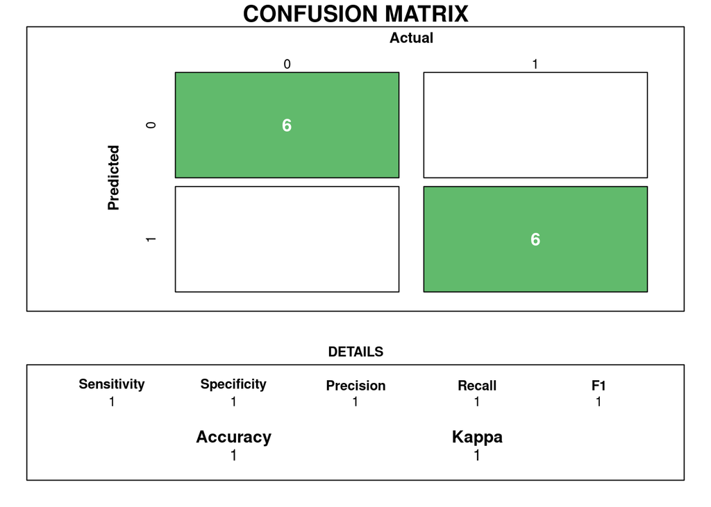

```r
cm = caret::confusionMatrix(factor(y_pred), factor(actual))
draw_confusion_matrix(cm)
```

```r
print(importance[1:10,])
```

```
    Feature Gain Cover Frequency
 1: gestAge    1     1         1
 2:    <NA>   NA    NA        NA
 3:    <NA>   NA    NA        NA
 4:    <NA>   NA    NA        NA
 5:    <NA>   NA    NA        NA
 6:    <NA>   NA    NA        NA
 7:    <NA>   NA    NA        NA
 8:    <NA>   NA    NA        NA
 9:    <NA>   NA    NA        NA
10:    <NA>   NA    NA        NA
```

```r
cm
```

```
Confusion Matrix and Statistics

          Reference
Prediction 0 1
         0 6 0
         1 0 6

               Accuracy : 1
                 95% CI : (0.7354, 1)
    No Information Rate : 0.5
    P-Value [Acc > NIR] : 0.0002441

                  Kappa : 1
 Mcnemar's Test P-Value : NA

            Sensitivity : 1.0
            Specificity : 1.0
         Pos Pred Value : 1.0
         Neg Pred Value : 1.0
             Prevalence : 0.5
         Detection Rate : 0.5
   Detection Prevalence : 0.5
      Balanced Accuracy : 1.0

       'Positive' Class : 0
```

```r
# rmarkdown::render('main.rmd')
```